# **Performance Metrics: Confusion matrix**

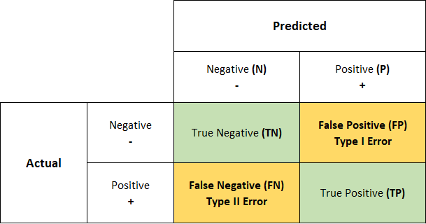

- A Confusion matrix is an N x N matrix used for evaluating the performance of a classification model, where N is the number of target classes. The matrix compares the actual target values with those predicted by the machine learning model.

1.A good model is one which has high TP and TN rates, while low FP and FN rates.

2.If you have an imbalanced dataset to work with, it’s always better to use confusion matrix as your evaluation criteria for your machine learning model.

The following 4 are the basic terminology which will help us in determining the metrics we are looking for.

- **True Positives (TP):** when the actual value is Positive and predicted is also Positive.
- **True negatives (TN):** when the actual value is Negative and prediction is also Negative.
- **False positives (FP):** When the actual is negative but prediction is Positive. Also known as the Type 1 error
- **False negatives (FN):** When the actual is Positive but the prediction is Negative. Also known as the Type 2 error

**Multi-Class Confusion Matrix**

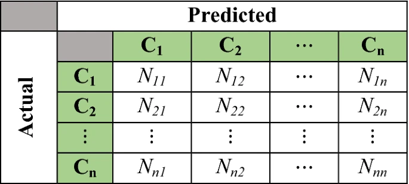

**Defining the confusion matrix**

```python
Y_pred = model.predict_generator(validation_generator, validation_generator.samples  // batch_size+1)
y_pred = np.argmax(Y_pred, axis=1)
print('Confusion Matrix')
print(confusion_matrix(validation_generator.classes, y_pred))
```

[output not shown]

```python
cm=confusion_matrix(validation_generator.classes, y_pred)
```

Complete the function plot_confusion_matrix that prints and plots the confusion matrix.

```python
def plot_confusion_matrix(cm, classes,
                          normalize=False,
                          title='Confusion matrix',
                          cmap=plt.cm.Blues):
    """
    This function prints and plots the confusion matrix.
    Normalization can be applied by setting `normalize=True`.
    """
    if normalize:
        cm = cm.astype('float') / cm.sum(axis=1)[:, np.newaxis]
        print("Normalized confusion matrix")
    else:
        print('Confusion matrix, without normalization')

    print(cm)
    plt.imshow(cm, interpolation='nearest', cmap=cmap)
    plt.title(title)
    plt.colorbar()
    plt.tight_layout()
    plt.ylabel('True label')
    plt.xlabel('Predicted label')
```

```python
category_names = sorted(os.listdir('/content/drive/MyDrive/FrenchCarsSplit/train'))
```

```python
plot_confusion_matrix(cm, category_names,
                          normalize=True,
                          title='Confusion matrix',
                          cmap=plt.cm.Blues)
```

[output not shown]

**TO DO**

Try to find the Recall , precision and F1-score in the classification report function

```python
print('Classification Report')
print(classification_report(validation_generator.classes, y_pred))
```

[output not shown]